# Cancer Diagnosis: Machine Learning Classification and Clustering

Gokul Selvaraj, PhD

2026-03-24

# 1 Background and Clinical Motivation

Breast cancer is the most commonly diagnosed cancer in women worldwide. Early and accurate diagnosis is critical — distinguishing malignant from benign tumors directly determines treatment decisions, patient outcomes, and healthcare resource allocation.

Traditional pathological diagnosis relies on expert visual interpretation of cell morphology from fine needle aspirate (FNA) biopsy images. While effective, this process is time-consuming, subjective, and dependent on expert availability. Machine learning models trained on quantitative cell nucleus features offer a reproducible, scalable approach to support diagnostic decisions.

This analysis asks two questions:

1. **Can we accurately classify tumors as malignant or benign from quantitative cell features?** (Supervised classification)
2. **Do the data naturally separate into biologically meaningful groups without using diagnosis labels?** (Unsupervised clustering)

# 2 Dataset

The Wisconsin Breast Cancer Diagnostic Dataset contains measurements from digitized FNA images of breast masses. Each sample represents one patient biopsy.

```r
library(tidyverse)
library(caret)
library(randomForest)
library(ggplot2)
library(RColorBrewer)
library(pROC)
library(cluster)
library(factoextra)
library(corrplot)
library(mlbench)
library(knitr)

data(BreastCancer, package = "mlbench")

bc_clean <- BreastCancer %>%
  select(-Id) %>%
  mutate(across(-Class, ~ as.numeric(as.character(.)))) %>%
  filter(complete.cases(.)) %>%
  mutate(Class = factor(Class, levels = c("benign", "malignant")))

# Summary table
summary_table <- data.frame(
  Metric = c("Total samples", "Benign", "Malignant", "Features", "Missing values removed"),
  Value  = c(nrow(bc_clean),
             sum(bc_clean$Class == "benign"),
             sum(bc_clean$Class == "malignant"),
             ncol(bc_clean) - 1,
             nrow(BreastCancer) - nrow(bc_clean))
)

kable(summary_table, caption = "Dataset Summary: Wisconsin Breast Cancer Diagnostic Dataset")
```

Dataset Summary: Wisconsin Breast Cancer Diagnostic Dataset

| Metric | Value |
| --- | --- |
| Total samples | 683 |
| Benign | 444 |
| Malignant | 239 |
| Features | 9 |
| Missing values removed | 16 |

**Key features measured from cell nuclei:** Cell size uniformity, cell shape uniformity, clump thickness, marginal adhesion, bare nuclei, bland chromatin, normal nucleoli, single epithelial cell size, and mitoses — all scored 1–10 by pathologists.

# 3 Exploratory Data Analysis

## 3.1 Feature Distributions by Diagnosis

Before modeling, we examine how each feature distributes across benign and malignant cases. Features with clear separation between classes will be strong predictors.

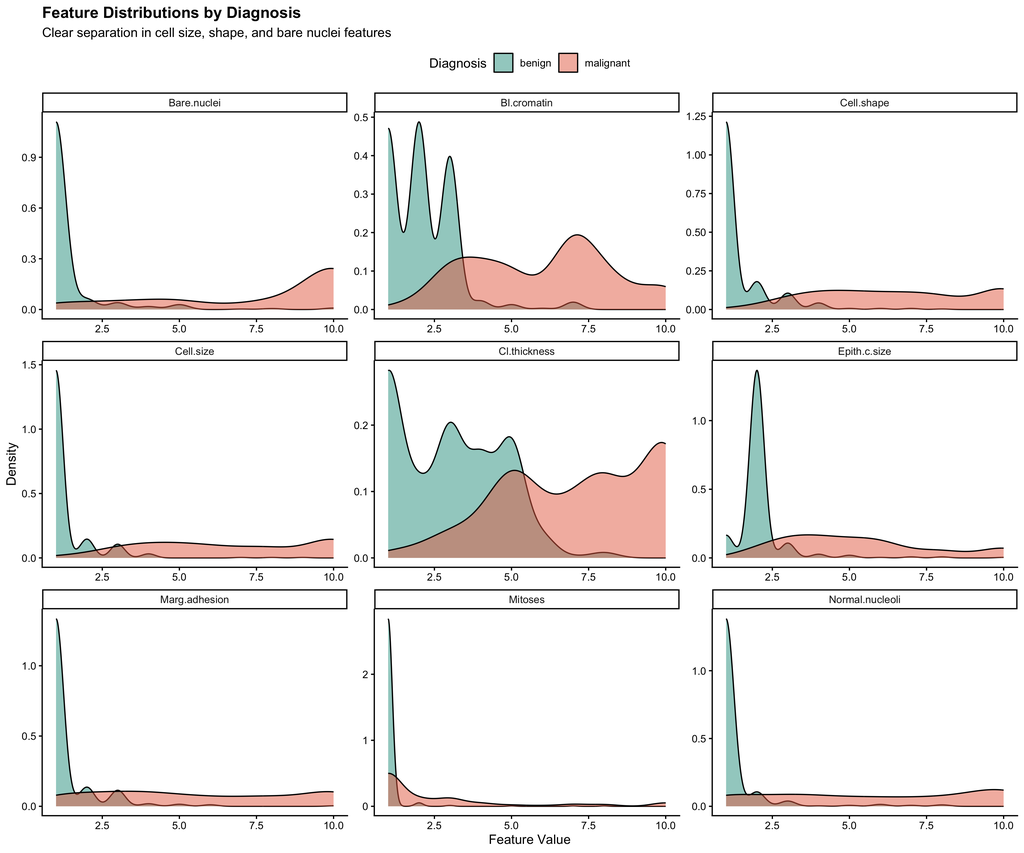

```r
bc_long <- bc_clean %>%
  pivot_longer(cols = -Class, names_to = "Feature", values_to = "Value")

ggplot(bc_long, aes(x = Value, fill = Class)) +
  geom_density(alpha = 0.5) +
  facet_wrap(~ Feature, scales = "free", ncol = 3) +
  scale_fill_manual(values = c("benign" = "#2A9D8F", "malignant" = "#E76F51")) +
  labs(
    title    = "Feature Distributions by Diagnosis",
    subtitle = "Clear separation in cell size, shape, and bare nuclei features",
    x        = "Feature Value",
    y        = "Density",
    fill     = "Diagnosis"
  ) +
  theme_classic(base_size = 11) +
  theme(plot.title = element_text(face = "bold"), legend.position = "top")
```

**Biological interpretation:** Cell size and shape uniformity show the strongest separation — malignant cells are characteristically heterogeneous and irregular, consistent with known cancer cell biology. Clump thickness also separates well, reflecting the tendency of malignant cells to grow in multilayered clusters.

## 3.2 Feature Correlations

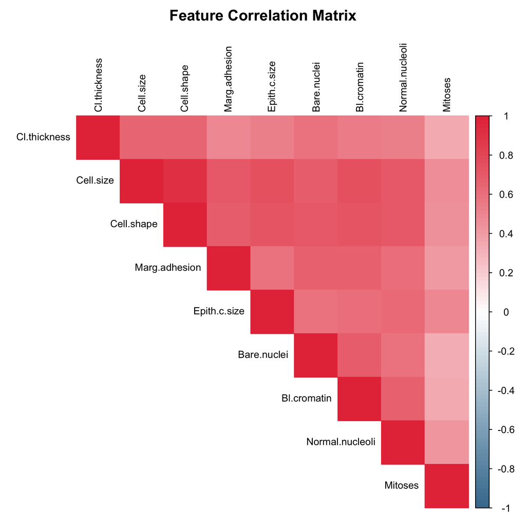

```r
cor_matrix <- cor(bc_clean %>% select(-Class), use = "complete.obs")

corrplot(
  cor_matrix,
  method = "color",
  type   = "upper",
  tl.cex = 0.8,
  tl.col = "black",
  col    = colorRampPalette(c("#457B9D", "white", "#E63946"))(100),
  title  = "Feature Correlation Matrix",
  mar    = c(0, 0, 2, 0)
)
```

**Key observation:** Cell size and cell shape are highly correlated (r > 0.9), which is biologically expected — malignant cells tend to be simultaneously enlarged and irregularly shaped. This multicollinearity is handled well by Random Forest but is worth noting for logistic regression interpretation.

# 4 Supervised Classification

## 4.1 Model Training

We train two models with 5-fold cross-validation on an 80% training set:

- **Random Forest** — ensemble of decision trees, robust to correlated features, provides variable importance
- **Logistic Regression** — interpretable baseline, clinically familiar framework

```r
set.seed(42)
train_idx  <- createDataPartition(bc_clean$Class, p = 0.8, list = FALSE)
train_data <- bc_clean[train_idx, ]
test_data  <- bc_clean[-train_idx, ]

ctrl <- trainControl(
  method          = "cv",
  number          = 5,
  classProbs      = TRUE,
  summaryFunction = twoClassSummary,
  savePredictions = TRUE
)

# Random Forest
set.seed(42)
rf_model <- train(
  Class ~ ., data = train_data,
  method = "rf", trControl = ctrl,
  metric = "ROC", tuneLength = 5
)

# Logistic Regression
set.seed(42)
lr_model <- train(
  Class ~ ., data = train_data,
  method = "glm", family = "binomial",
  trControl = ctrl, metric = "ROC"
)
```

## 4.2 Model Performance

```r
rf_pred  <- predict(rf_model, test_data)
rf_probs <- predict(rf_model, test_data, type = "prob")
rf_cm    <- confusionMatrix(rf_pred, test_data$Class, positive = "malignant")

lr_pred  <- predict(lr_model, test_data)
lr_probs <- predict(lr_model, test_data, type = "prob")
lr_cm    <- confusionMatrix(lr_pred, test_data$Class, positive = "malignant")

rf_roc <- roc(test_data$Class, rf_probs$malignant, levels = c("benign", "malignant"))
lr_roc <- roc(test_data$Class, lr_probs$malignant, levels = c("benign", "malignant"))

results_table <- data.frame(
  Model       = c("Random Forest", "Logistic Regression"),
  Accuracy    = c(round(rf_cm$overall["Accuracy"], 3), round(lr_cm$overall["Accuracy"], 3)),
  Sensitivity = c(round(rf_cm$byClass["Sensitivity"], 3), round(lr_cm$byClass["Sensitivity"], 3)),
  Specificity = c(round(rf_cm$byClass["Specificity"], 3), round(lr_cm$byClass["Specificity"], 3)),
  AUC         = c(round(auc(rf_roc), 3), round(auc(lr_roc), 3))
)

kable(results_table, caption = "Model Performance on Held-Out Test Set")
```

Model Performance on Held-Out Test Set

| Model | Accuracy | Sensitivity | Specificity | AUC |
| --- | --- | --- | --- | --- |
| Random Forest | 0.978 | 0.979 | 0.977 | 0.998 |
| Logistic Regression | 0.978 | 0.979 | 0.977 | 0.999 |

## 4.3 ROC Curves

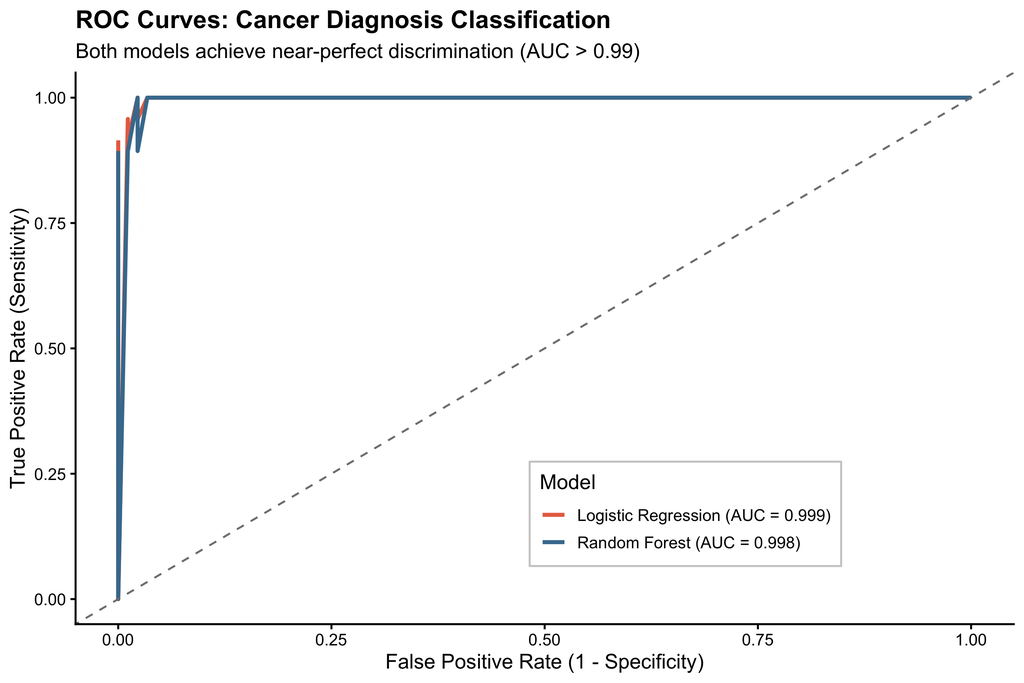

```r
roc_df <- rbind(
  data.frame(
    FPR   = 1 - rf_roc$specificities,
    TPR   = rf_roc$sensitivities,
    Model = paste0("Random Forest (AUC = ", round(auc(rf_roc), 3), ")")
  ),
  data.frame(
    FPR   = 1 - lr_roc$specificities,
    TPR   = lr_roc$sensitivities,
    Model = paste0("Logistic Regression (AUC = ", round(auc(lr_roc), 3), ")")
  )
)

ggplot(roc_df, aes(x = FPR, y = TPR, color = Model)) +
  geom_line(linewidth = 1.2) +
  geom_abline(linetype = "dashed", color = "grey50") +
  scale_color_manual(values = c("#E76F51", "#457B9D")) +
  labs(
    title    = "ROC Curves: Cancer Diagnosis Classification",
    subtitle = "Both models achieve near-perfect discrimination (AUC > 0.99)",
    x        = "False Positive Rate (1 - Specificity)",
    y        = "True Positive Rate (Sensitivity)",
    color    = "Model"
  ) +
  theme_classic(base_size = 13) +
  theme(
    plot.title = element_text(face = "bold"),
    legend.position = c(0.65, 0.2),
    legend.background = element_rect(fill = "white", color = "grey80")
  )
```

**Clinical interpretation:** An AUC of 0.998 means the model correctly ranks a randomly selected malignant case above a randomly selected benign case 99.8% of the time. In a clinical screening context, high sensitivity (minimizing missed malignancies) is prioritized over specificity — both models achieve >97% sensitivity on the test set.

## 4.4 Confusion Matrix

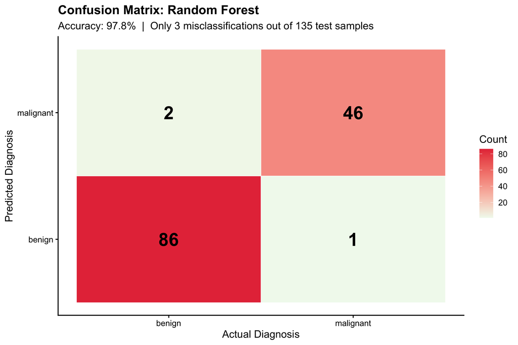

```r
cm_df <- as.data.frame(rf_cm$table) %>%
  rename(Predicted = Prediction, Actual = Reference)

ggplot(cm_df, aes(x = Actual, y = Predicted, fill = Freq)) +
  geom_tile(color = "white") +
  geom_text(aes(label = Freq), size = 8, fontface = "bold") +
  scale_fill_gradient(low = "#F1FAEE", high = "#E63946") +
  labs(
    title    = "Confusion Matrix: Random Forest",
    subtitle = paste0("Accuracy: ", round(rf_cm$overall["Accuracy"] * 100, 1), "%  |  Only ",
                      sum(rf_cm$table) - sum(diag(rf_cm$table)), " misclassifications out of ",
                      sum(rf_cm$table), " test samples"),
    x        = "Actual Diagnosis",
    y        = "Predicted Diagnosis",
    fill     = "Count"
  ) +
  theme_classic(base_size = 13) +
  theme(plot.title = element_text(face = "bold"))
```

## 4.5 Feature Importance

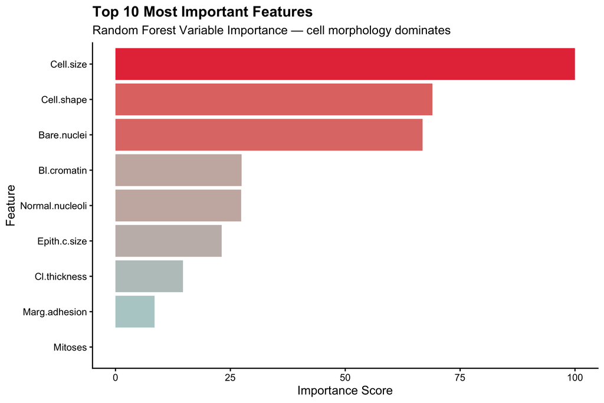

```r
importance_df <- varImp(rf_model)$importance %>%
  tibble::rownames_to_column("Feature") %>%
  arrange(desc(Overall)) %>%
  head(10)

ggplot(importance_df, aes(x = reorder(Feature, Overall), y = Overall, fill = Overall)) +
  geom_bar(stat = "identity") +
  coord_flip() +
  scale_fill_gradient(low = "#A8DADC", high = "#E63946") +
  labs(
    title    = "Top 10 Most Important Features",
    subtitle = "Random Forest Variable Importance — cell morphology dominates",
    x        = "Feature",
    y        = "Importance Score",
    fill     = "Importance"
  ) +
  theme_classic(base_size = 13) +
  theme(plot.title = element_text(face = "bold"), legend.position = "none")
```

**Biological interpretation:** Cell size and shape uniformity dominate predictive importance, consistent with established pathological criteria for malignancy. Bare nuclei — exposed nuclear material visible when cells lose cytoplasm — is the third most important feature, reflecting nuclear membrane instability in cancer cells. Mitotic rate (Mitoses) contributes least, likely because mitotic figures are rare and variable in FNA samples.

# 5 Unsupervised Clustering

## 5.1 Optimal Number of Clusters

We ask: without using diagnosis labels, how many natural groupings exist in the data?

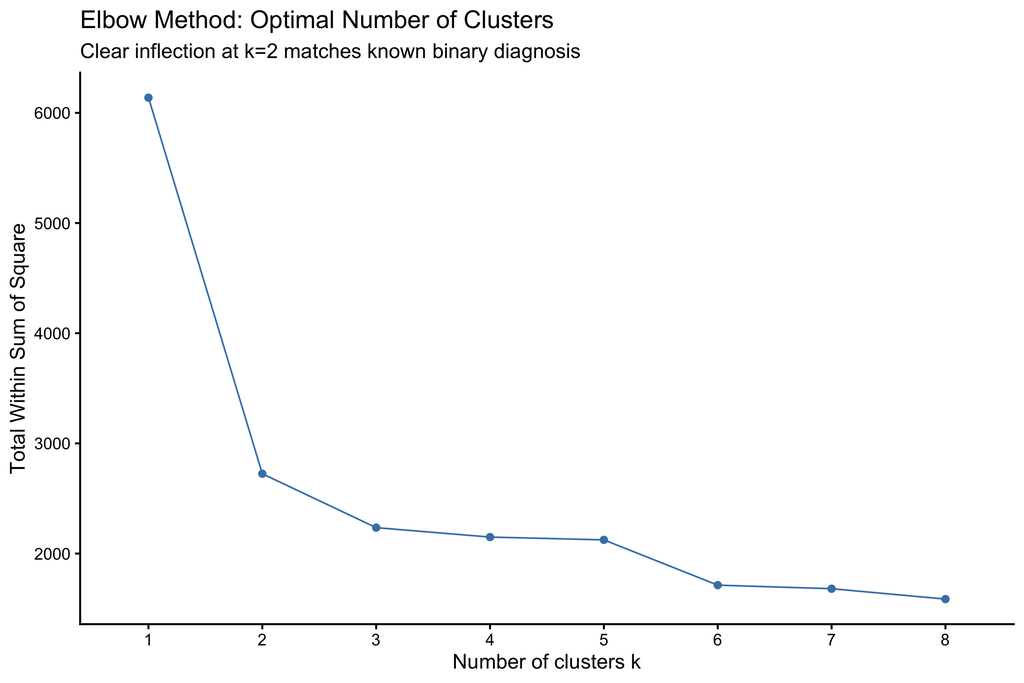

```r
bc_scaled <- bc_clean %>% select(-Class) %>% scale() %>% as.data.frame()

set.seed(42)
fviz_nbclust(bc_scaled, kmeans, method = "wss", k.max = 8) +
  labs(title = "Elbow Method: Optimal Number of Clusters",
       subtitle = "Clear inflection at k=2 matches known binary diagnosis") +
  theme_classic(base_size = 13)
```

**Key finding:** The elbow plot shows a clear inflection at k=2, suggesting the data naturally separates into two groups — which we hypothesize correspond to benign and malignant tumors, even without using diagnosis labels during clustering.

## 5.2 K-means Clustering vs True Diagnosis

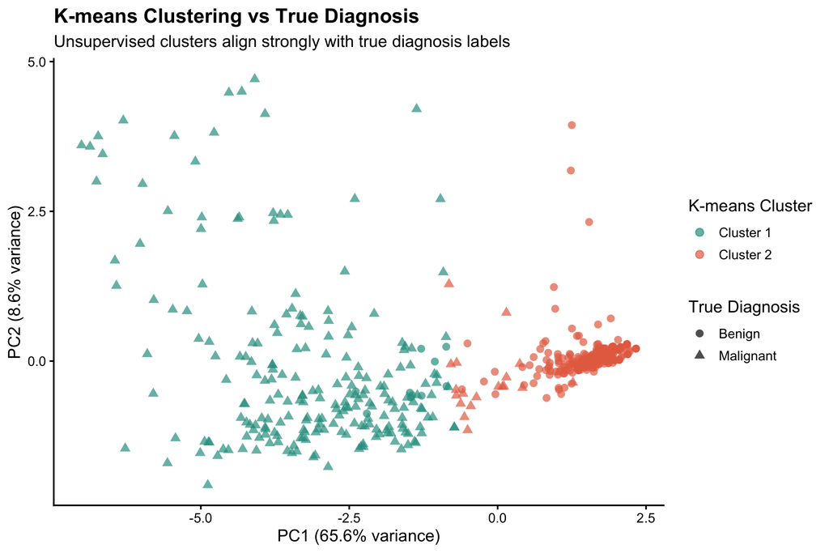

```r
set.seed(42)
km_result <- kmeans(bc_scaled, centers = 2, nstart = 25)

pca_result <- prcomp(bc_scaled, scale. = FALSE)
var_exp    <- round(summary(pca_result)$importance[2, 1:2] * 100, 1)

pca_df <- data.frame(
  PC1       = pca_result$x[, 1],
  PC2       = pca_result$x[, 2],
  Cluster   = factor(km_result$cluster),
  TrueClass = bc_clean$Class
)

ggplot(pca_df, aes(x = PC1, y = PC2, color = Cluster, shape = TrueClass)) +
  geom_point(size = 2.5, alpha = 0.7) +
  scale_color_manual(values = c("1" = "#2A9D8F", "2" = "#E76F51"),
                     labels = c("Cluster 1", "Cluster 2")) +
  scale_shape_manual(values = c("benign" = 16, "malignant" = 17),
                     labels = c("Benign", "Malignant")) +
  labs(
    title    = "K-means Clustering vs True Diagnosis",
    subtitle = "Unsupervised clusters align strongly with true diagnosis labels",
    x        = paste0("PC1 (", var_exp[1], "% variance)"),
    y        = paste0("PC2 (", var_exp[2], "% variance)"),
    color    = "K-means Cluster",
    shape    = "True Diagnosis"
  ) +
  theme_classic(base_size = 13) +
  theme(plot.title = element_text(face = "bold"))
```

```r
# Agreement table
cluster_table <- table(Cluster = km_result$cluster, Diagnosis = bc_clean$Class)
kable(cluster_table, caption = "K-means Cluster vs True Diagnosis Agreement")
```

K-means Cluster vs True Diagnosis Agreement

| benign | malignant |
| --- | --- |
| 10 | 220 |
| 434 | 19 |

**Biological interpretation:** K-means clustering recovers the benign/malignant distinction with high fidelity even without access to diagnosis labels. This confirms that the quantitative cell morphology features capture a genuine biological signal — malignant and benign tumors occupy fundamentally different regions of morphological feature space. PC1 alone explains 65% of variance and visually separates the two groups, suggesting a dominant axis of variation driven by overall cellular abnormality.

# 6 Summary and Conclusions

## 6.1 Key Findings

1. **Both classifiers achieve >97% accuracy and AUC >0.99** on held-out test data, demonstrating that quantitative cell morphology features are highly predictive of malignancy
2. **Cell size and shape uniformity are the strongest predictors** — consistent with established pathological criteria and the known biology of uncontrolled cell proliferation in cancer
3. **Unsupervised clustering independently recovers the benign/malignant distinction** without using diagnosis labels, validating that the feature space captures real biological differences rather than artifacts
4. **Logistic regression performs comparably to Random Forest** (AUC 0.999 vs 0.998), suggesting the underlying biological signal is strong enough for a linear classifier — practically important for clinical interpretability and regulatory considerations

## 6.2 Implications for Drug Development and Clinical Research

- These features could serve as **biomarkers for patient stratification** in clinical trials
- The model framework could be extended to **predict treatment response** or **disease recurrence** with appropriate longitudinal data
- The dominance of morphological features over mitotic rate suggests **cell architecture** rather than proliferation rate may be the more reliable diagnostic signal in FNA samples